## **Long-tailed hopping mouse**

### Blamed on cats

[figure not shown]

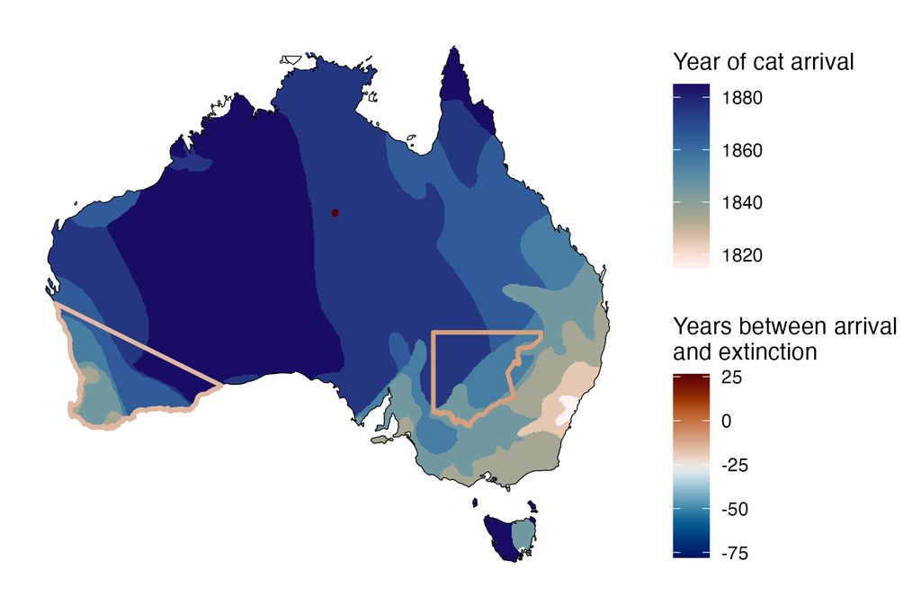

IUCN status: **Extinct**

Last seen: *Notomys longicaudatus were last seen in 1902 (1901-1902) in Barrow Creek, Northern Territory (IUCN 2023)*

IUCN claim: *“Extinction is attributed to predation by feral cats.”*

### Studies in support

Long-tailed hopping mice were last confirmed at Barrow Creek, NT, 21-32 years after cats arrived (Wallach and Lundgren 2025).

### Studies not in support

Long-tailed hopping mice were last confirmed in the Western Division of NSW and southwest Australia 35 and 50 years before, to 15 and 19 years after, cats arrived, respectively (Wallach and Lundgren 2025).

### Is the threat claim evidence-based?

In two regions it cannot be verified that extirpation occurred after cat arrival.

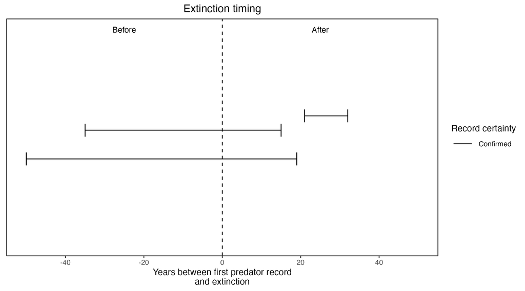

**Evidence linking *Notomys longicaudatus* to cats.** Last records of extirpated populations relative to earliest local records of cats. Error bars show record uncertainty range. Predator arrival records were digitized from Abbott 2008.

### References

Abbott, The spread of the cat, Felis catus, in Australia: re-examination of the current conceptual model with additional information. Conservation Science Western Australia 7 (2008).

IUCN Red List. https://www.iucnredlist.org/ Accessed June 2023

Wallach A.D., Lundgren E.J. (2025) Review of evidence that foxes and cats cause extinctions of Australia’s endemic mammals. BioScience. DOI: 10.1093/biosci/biaf046